# cscb.tools

Arta Seyedian and David Smith

2023-01-13

# Introduction

`{cscb.tools}` is a set of utility wrapper functions designed to work with a Seurat-based approach to single-cell analysis. The standard workflow for CSCB’s Seurat-based preprocessing steps are as follows:

1. SoupX
2. Create Seurat Object
3. Mito/Ribo plotting and filtering
4. Preprocessing
5. DoubletFinder
6. Visualization
7. (optional) ComBat Batch correction

This vignette will provide an overview of each/all of these steps in the context of a single-cell analysis workflow.

## Requirements

The following libraries are required for the proper functioning of these tools:

```r
require(Seurat)
require(ggplot2)
require(DoubletFinder)
require(SoupX)
require(sva)
require(reticulate)
```

Additionally, you will need to set up reticulate to use a conda environment with ScanPy. The default environment is `r-reticulate`, so it may be easiest to install to that conda environment:

```
reticulate::use_condaenv("{Insert Conda Environment Here")
```

or

```
reticulate::conda_install("r-reticulate", "ScanPy")
```

# General Workflow

Below, we will overview the basic steps in implementing these tools in a single-cell RNA seq analysis.

## SoupX (Multi)

If loading 10x CellRanger `multi` results as part of a VDJ or multiome experiment, you can use `soupx_load_multi` to consolidate all relevant data into a singular SoupX object that can be later converted to a Seurat object.

```r
# Obtain paths for all samples
gex_multi_soup_raw <-
  R.utils::getAbsolutePath(Sys.glob(
    file.path(
      "../../SCTC-X/Data_Analysis/xxx-vdj-gex/code/02-multi/runs/*_VDJ_GEX/outs/multi/count/raw_feature_bc_matrix/"
    )
  ))

gex_multi_soup_filtered <-
  R.utils::getAbsolutePath(Sys.glob(
    file.path(
      "../../SCTC-X/Data_Analysis/xxx-vdj-gex/code/02-multi/runs/*_VDJ_GEX/outs/per_sample_outs/*_VDJ_GEX/count/sample_filtered_feature_bc_matrix/"
    )
  ))

gex_multi_soup_clusters <-
  R.utils::getAbsolutePath(Sys.glob(
    file.path(
      "../../SCTC-X/Data_Analysis/xxx-vdj-gex/code/02-multi/runs/*_VDJ_GEX/outs/per_sample_outs/*_VDJ_GEX/count/analysis/clustering/gene_expression_graphclust/clusters.csv"
    )
  ))

# setting these to null is important for cell-naming purposes;
# Seurat will use the relative path set in the name of the absolute paths
# to generate cell barcodes. Not good.
names(gex_multi_soup_raw) <- NULL
names(gex_multi_soup_filtered) <- NULL
names(gex_multi_soup_clusters) <- NULL

gex_obj <- list()
```

`adjustCounts` generates plots, so be sure to capture them using `pdf()`:

```r
pdf(
  here("processed/xxx/SoupX_contam_frac.pdf"),
  height = 8,
  width = 11
)

for (i in 1:length(gex_multi_soup_raw)) {
  gex_obj[[i]] <-
    soupx_load_multi(gex_multi_soup_raw[i],
                     gex_multi_soup_filtered[i],
                     gex_multi_soup_clusters[i])
  gex_obj[[i]] <- autoEstCont(gex_obj[[i]], soupQuantile = 0.5)
  gex_obj[[i]] <-  adjustCounts(gex_obj[[i]])
}

dev.off()
```

Now, you may use the SoupX ambient RNA calculations to create Seurat objects:

```r
gex_names <- c("a", "b", "c", "d", "e", "f")

for (i in 1:length(gex_obj)) {
  gex_obj[[i]] <-
    CreateSeuratObject(gex_obj[[i]], project = gex_names[i])
}

names(gex_obj) <- gex_names
```

## Calculating Mitochondrial and Ribosomal Gene Content

`get_percent` calculates both the percent mitochondrial and percent ribosomal genes in every cell. It does so by calling Seurat’s `PercentageFeatureSet` for genes beginning with the strings `MT` or `RPS`.

```r
for (i in 1:length(gex_obj)) {
  gex_obj[[i]] <- get_percent(gex_obj[[i]])
}
```

You can then plot the number of read counts vs the number of genes using `seurat_counts` as well as the percentages of mitochondrial and ribosomal genes per cell using `plot_mito`:

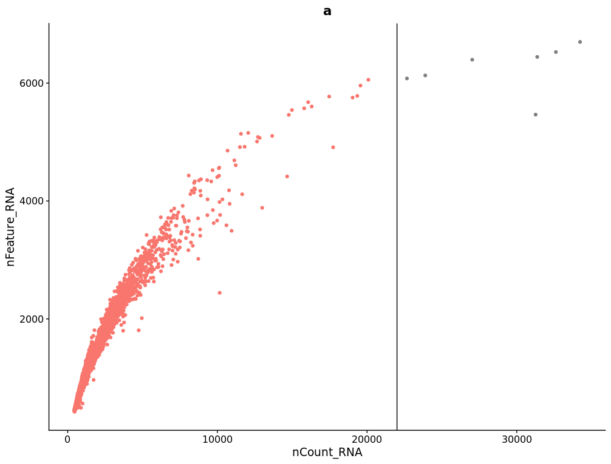

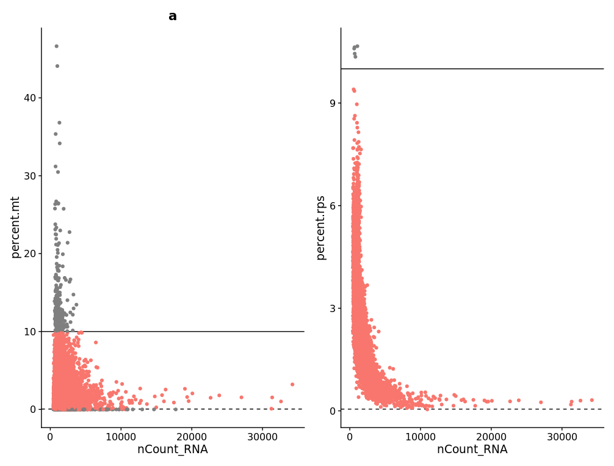

```r
seurat_counts(gex_obj[[1]], count.cutoff = 22000) + ggtitle(gex_names[[1]])
plot_mito(gex_obj[[1]], title = gex_names[[1]])
```

## Seurat Preprocessing

The most involved and potentially important function in our single cell analysis workflow is `seurat_process`. This function prunes cells that do not meet certain cutoff criteria and optionally adjusts the overall gene expression profile for cell cycle genes. Here, I will explicitly write out the default arguments, but note that as they are defaults, they do not need to be specified each time.

One argument, which you absolutely need to supply, is `count.cutoff`. This value is the same as the one used in and can be obtained from `seurat_counts`.

```r
count_cutoffs <- c(22000, 52000, 10000, 70000, 65000, 60000)

for (i in 1:length(gex_obj)) {
  gex_obj[[i]] <-
    seurat_process(
      gex_obj[[i]],
      counts_name = gex_names[[i]],
      count.cutoff = count_cutoffs[i],
      mito.cutoff = 10,
      rps.cutoff = 10,
      cc_adjust = FALSE
    )
}
```

## DoubletFinder

```r
gex_pk <- list()

for (i in 1:length(gex_obj)) {
  message(crayon::red$underline$bold(
    paste0("Finding Parameter Sweep with DoubletFinder for ", gex_names[[i]])
  ))
  gex_pk[[i]] <-
    sum.sweep(gex_obj[[i]])
  message(crayon::red$underline$bold(paste0("Saving ", gex_names[[i]])))
}
```

```r
pdf(here("processed/01-5_3-comp/ParamSweepPeaks_count_cutoffs.pdf"))

plot_pk(gex_pk[[1]], title = gex_names[[1]])
plot_pk(gex_pk[[2]], title = gex_names[[2]])
plot_pk(gex_pk[[3]], title = gex_names[[3]])
plot_pk(gex_pk[[4]], title = gex_names[[4]])
plot_pk(gex_pk[[5]], title = gex_names[[5]])
plot_pk(gex_pk[[6]], title = gex_names[[6]])

dev.off()
```

```r
gex_doubs <- list()

# options(future.globals.maxSize = 2500 * 1024^2)

for (i in 1:length(gex_obj)) {
  message(crayon::red$underline$bold(paste0(
    "Finding Doublets with DoubletFinder for ", gex_names[[i]]
  )))
  gex_doubs[[i]] <-
    doubFinder(gex_obj[[i]],
               sweep.stats.sample = gex_pk[[i]],
               rm.doubs = TRUE)
  message(crayon::red$underline$bold(paste0("Saving ", gex_names[[i]])))
}

pdf(
  here("processed/xxx/GEX_doubletClusters_removed.pdf"),
  height = 8,
  width = 14
)

viz.doubs(gex_doubs[[1]], title = gex_names[[1]])
viz.doubs(gex_doubs[[2]], title = gex_names[[2]])
viz.doubs(gex_doubs[[3]], title = gex_names[[3]])
viz.doubs(gex_doubs[[4]], title = gex_names[[4]])
viz.doubs(gex_doubs[[5]], title = gex_names[[5]])
viz.doubs(gex_doubs[[6]], title = gex_names[[6]])

dev.off()
```

## ComBat Batch Correction

The `process_combat` function is a helper function that is used to correct for batch effects in single-cell RNA sequencing (scRNA-seq) data using the ComBat algorithm. It takes in a `seuratObj` object and a `seuratBatch` variable as inputs, and returns the `seuratObj` with corrected data in a new assay called `combatBatch.` This function can be used to apply the ComBat algorithm in a streamlined manner within a Seurat workflow, making the analysis of scRNA-seq data more accurate by removing batch effects. Batch effect can be caused by technical variations between different batches of scRNA-seq data, and removing them is crucial for proper analysis and interpretation of the data.

Note that you can either merge the desired batches yourself prior to calling `process_combat`, or you can create a vector of Seurat objects yourself and have the function do it for you by setting `merge = TRUE` (default FALSE). Here we merged first.

```r
for (i in 1:length(rna_seq)) {
  rna_seq[[i]] <-
    RenameCells(rna_seq[[i]],
                new.names = sub("_[^_]+$", "", colnames(rna_seq[[i]])))
}

ComBat_merge <-
  merge(
    rna_seq[[1]],
    y = c(
      rna_seq[[2]],
      rna_seq[[3]],
      rna_seq[[4]],
      rna_seq[[5]],
      rna_seq[[6]],
      gex_doubs[[1]],
      gex_doubs[[2]],
      gex_doubs[[3]],
      gex_doubs[[4]],
      gex_doubs[[5]],
      gex_doubs[[6]]
    )
  )

ComBat_merge <- ComBat_merge[, ComBat_merge$doublet == "Singlet"]

combat_proccess <-
   process_combat(ComBat_merge, seuratObj$comp.ident)
```

## Delete Genes from Seurat Object Assay

Sometimes you want to remove certain specific genes from your Seurat object, like mitochondrial genes (`MT-`) or ribosomal genes (`RPS`), or maybe you have a vector of gene names you want to remove instead. You can use `del_genes` to do so.

```r
seuratObj <- del_genes(seuratObj, "HLA")
# multiple genes
gene_name_prefixes <- c("HLA", "RPS", "RPL", "IG")
seuratObj <- del_genes(seuratObj, gene_name_prefixes, assay = "SCT")
```

## Fixing cellxgene Indexing Issue

The package `SeuratDisk` is helpful for converting between HDF5 filetypes, but has certain kinks that are hard to work out. One of these kinks is the fact that converting a Seurat object to `h5ad` causes an issue with the [var names indexing](https://github.com/theislab/scvelo/issues/255#issuecomment-739995301). Fortunately, there is a solution. This function depends on having Python installed with ScanPy.

```r
SaveH5Seurat(
  samples.combined,
  filename = "processed/02-annotation/cellxgene_out_UNFILTERED_no4k_doublets.h5Seurat",
  verbose = TRUE,
  overwrite = TRUE
)

Convert(
  source = "processed/02-annotation/cellxgene_out_UNFILTERED_no4k_doublets.h5Seurat",
  dest = "h5ad",
  assay = "combatBatch",
  verbose = TRUE,
  overwrite = TRUE
)

fix_cellxgene(file = "processed/02-annotation/cellxgene_out_UNFILTERED_no4k_doublets.h5ad")
```